# Pho, Dim Sum & Sushi in the Crescent City

Where to find the best Vietnamese, Chinese & Japanese food in New Orleans: a Yelp data study in cleaning, joins, spatial analysis and reviewer-adjusted ratings

Author

Samuel Lin

Published

November 15, 2026

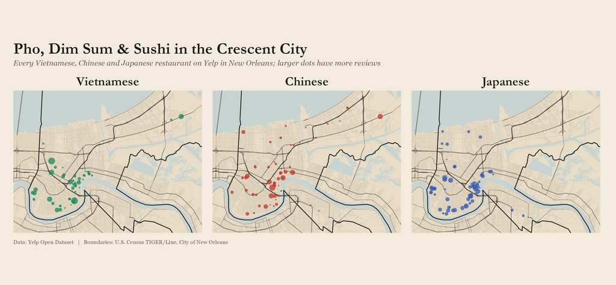

## Research question

> **Where can someone find the best Vietnamese, Chinese, and Japanese restaurants in New Orleans, and which neighborhood is the best place to look?**

## Executive summary

### The top 10

```r
top10 |> select(rank, restaurant, cuisine, area, reviews, avg_stars, avg_normalized) |> show()
```

| rank | restaurant | cuisine | area | reviews | avg_stars | avg_normalized |
| --- | --- | --- | --- | --- | --- | --- |
| 1 | Tito’s Ceviche & Pisco | Japanese | Uptown | 221 | 4.72 | 0.49 |
| 2 | Nagomi | Japanese | St. Claude | 24 | 4.96 | 0.84 |
| 3 | Mister Mao | Chinese | West Riverside | 29 | 4.66 | 0.68 |
| 4 | Singleton’s Mini Mart | Vietnamese | Black Pearl | 91 | 4.53 | 0.48 |
| 5 | Asuka Sushi & Hibachi | Japanese | Gert Town | 316 | 4.40 | 0.39 |
| 6 | Dong Phuong | Chinese + Vietnamese | Village De Lest | 423 | 4.33 | 0.49 |
| 7 | Lilly’s Cafe | Vietnamese | Lower Garden District | 797 | 4.35 | 0.42 |
| 8 | Dian Xin | Chinese | French Quarter | 402 | 4.45 | 0.34 |
| 9 | Poke-chan | Japanese | St. Claude | 138 | 4.52 | 0.32 |
| 10 | Union Ramen | Japanese | Lower Garden District | 156 | 4.37 | 0.40 |

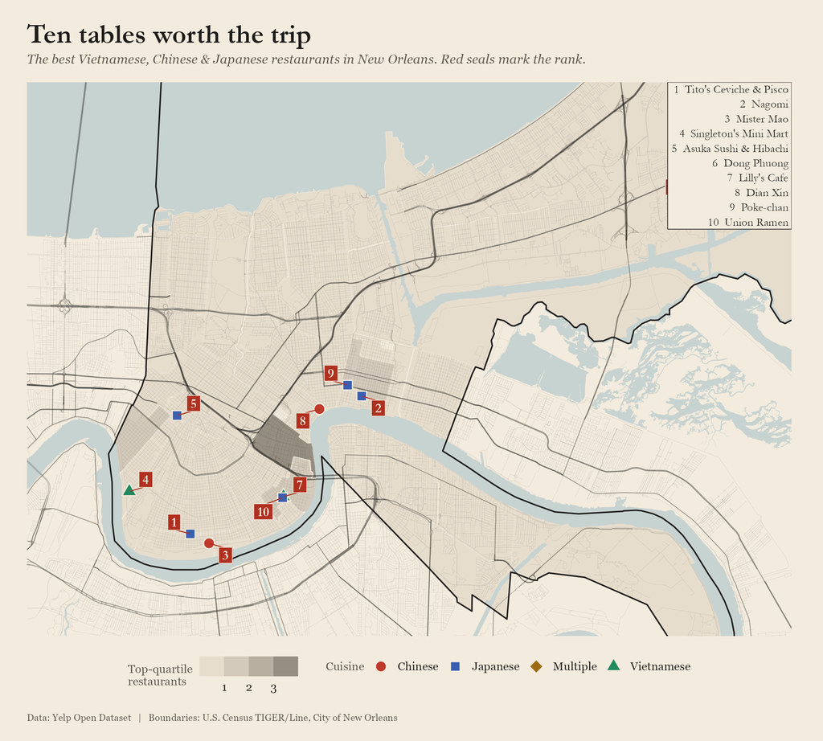

Final map: top 10 restaurants with neighborhood boundaries

[figure not shown]

The city fills in: restaurants appear in the year of their first Yelp review

## 1. Data and large-data management

```r
# =============================================================================
# R/01_import.R  —  run ONCE. Needs the raw Yelp JSON files in data/raw/.
#
# Large-data strategy:
#   * business file (~100 MB): small enough to read whole with stream_in().
#   * review file (~5 GB, ~7 million lines): NEVER loaded whole. stream_in()
#     reads it in pages of 100,000 lines; a handler keeps only reviews for
#     Louisiana restaurants and drops the long `text` column.
#   * results are saved as xz-compressed .rds files; after this script finishes
#     the raw JSON can be deleted.
# =============================================================================

source("R/00_setup.R")

business_file <- file.path(raw_dir, "yelp_academic_dataset_business.json")
review_file   <- file.path(raw_dir, "yelp_academic_dataset_review.json")
stopifnot(
  "Put yelp_academic_dataset_business.json in data/raw/" = file.exists(business_file),
  "Put yelp_academic_dataset_review.json in data/raw/"   = file.exists(review_file)
)

import_log <- tibble(step = character(), seconds = numeric(), rows = numeric(),
                     note = character())
log_step <- function(step, t0, rows, note = "") {
  import_log <<- add_row(import_log, step = step,
                         seconds = round(as.numeric(difftime(Sys.time(), t0, units = "secs")), 1),
                         rows = rows, note = note)
  message(step, ": ", rows, " rows")
}

# ---- 1. Business table ------------------------------------------------------
t0 <- Sys.time()
business_raw <- stream_in(file(business_file), verbose = FALSE)
log_step("read business JSON", t0, nrow(business_raw),
         paste0(round(file.size(business_file) / 1e6, 1), " MB on disk"))

business <- business_raw |>
  select(business_id, name, address, city, state, postal_code,
         latitude, longitude, stars, review_count, is_open, categories)
rm(business_raw); invisible(gc())

dim(business)
glimpse(business)

# Keep every Louisiana restaurant (not just city == "New Orleans") so the
# spatial join can find restaurants whose text label and location disagree.
la_restaurants <- business |>
  filter(state == "LA",
         !is.na(categories),
         str_detect(categories, regex("\\bRestaurants\\b", ignore_case = TRUE))) |>
  distinct(business_id, .keep_all = TRUE)

save_rds(la_restaurants, "la_restaurants")
log_step("Louisiana restaurants kept", t0, nrow(la_restaurants))

# Context numbers for the report
business_overview <- tibble(
  all_businesses        = nrow(business),
  louisiana_businesses  = sum(business$state == "LA", na.rm = TRUE),
  louisiana_restaurants = nrow(la_restaurants)
)
save_table(business_overview, "business_overview")
rm(business); invisible(gc())

# ---- 2. Review table, streamed in chunks ------------------------------------
keep_ids <- la_restaurants$business_id
review_cols <- c("review_id", "user_id", "business_id", "stars", "date",
                 "useful", "funny", "cool")

chunks <- list()
k <- 0
lines_read <- 0

t0 <- Sys.time()
stream_in(
  file(review_file),
  handler = function(df) {
    lines_read <<- lines_read + nrow(df)
    keep <- df[df$business_id %in% keep_ids, review_cols, drop = FALSE]
    if (nrow(keep) > 0) {
      k <<- k + 1
      chunks[[k]] <<- keep
    }
    if (lines_read %% 1e6 == 0) message(format(lines_read, big.mark = ",", scientific = FALSE), " reviews scanned")
  },
  pagesize = 100000,
  verbose = FALSE
)
la_reviews <- bind_rows(chunks)
rm(chunks); invisible(gc())
log_step("stream review JSON, keep LA restaurant reviews", t0, nrow(la_reviews),
         paste0(format(lines_read, big.mark = ",", scientific = FALSE), " reviews scanned; ",
                round(file.size(review_file) / 1e9, 1), " GB on disk"))

dim(la_reviews)
glimpse(la_reviews)

save_rds(la_reviews, "la_restaurant_reviews")
log_step("saved compressed .rds", t0, nrow(la_reviews),
         paste0(round(file.size(file.path(clean_dir, "la_restaurant_reviews.rds")) / 1e6, 1),
                " MB after xz compression"))

save_table(import_log, "import_log")
import_log
```

```r
tbl("import_log") |> show()
```

| step | seconds | rows | note |
| --- | --- | --- | --- |
| read business JSON | 16.1 | 150,346 | 118.9 MB on disk |
| Louisiana restaurants kept | 17.9 | 3,640 | NA |
| stream review JSON, keep LA restaurant reviews | 397.5 | 558,340 | 6,990,280 reviews scanned; 5.3 GB on disk |
| saved compressed .rds | 439.8 | 558,340 | 18.8 MB after xz compression |

- The review file is never loaded whole. `stream_in()` reads it 100,000 lines at a time and a handler keeps only reviews for Louisiana restaurants.
- The `text` column is dropped because the analysis uses stars, not review text, which removes most of the memory.
- Filtered data is saved as xz-compressed `.rds`; the raw JSON is git-ignored and can be deleted afterwards.

## 2. Defining a “New Orleans restaurant”

A business is a **restaurant** if its Yelp `categories` contain the word `Restaurants`. It is **in New Orleans** if its coordinates fall inside the official U.S. Census boundary of the City of New Orleans (which is the same as Orleans Parish). Yelp’s free-text `city` field was checked against that boundary rather than trusted.

```r
tbl("label_agreement") |> show()
```

| yelp_says_new_orleans | inside_official_nola | n | meaning |
| --- | --- | --- | --- |
| FALSE | FALSE | 177 | Agree: not New Orleans |
| TRUE | FALSE | 13 | Yelp says New Orleans, point is outside the city |
| TRUE | TRUE | 171 | Agree: New Orleans |

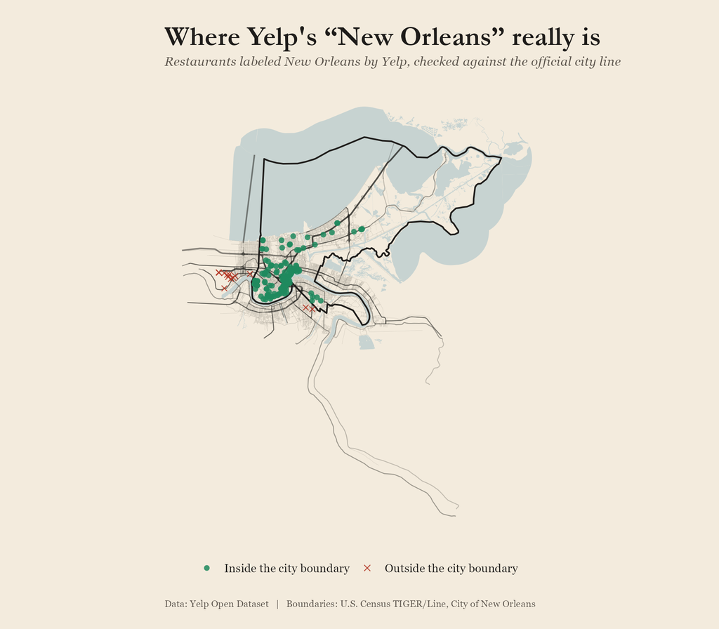

Yelp label vs official boundary

## 3. Choosing the categories

**Why these three belong together:** Vietnamese, Chinese, and Japanese are the three largest East and Southeast Asian cuisines in the city, they share dishes and formats (noodle soups, rice and noodle plates, dumplings, seafood), and diners often compare them when choosing “Asian food tonight.” New Orleans also has one of the largest Vietnamese communities in the U.S., which makes the comparison locally meaningful.

```r
# =============================================================================
# R/02_clean_categories.R
# Clean New Orleans restaurants, split categories, count and co-occur them,
# and apply the Vietnamese / Chinese / Japanese inclusion rule.
# Inputs : data/new_orleans/la_restaurants.rds
# Outputs: restaurant_categories.rds, asian_restaurants_text.rds, tables
# =============================================================================

source("R/00_setup.R")

la_restaurants <- read_rds_clean("la_restaurants")

# ---- 1. Clean fields --------------------------------------------------------
la_restaurants <- la_restaurants |>
  mutate(
    postal_code   = na_if(str_squish(postal_code), ""),
    categories    = str_squish(categories),
    business_name = str_squish(name),
    city_clean    = str_to_title(str_squish(city)),
    yelp_says_new_orleans = str_detect(str_to_lower(city_clean), "^new orleans|^nola$")
  )

# How is "New Orleans" spelled in the city field? (typos, "Nola", trailing text)
city_labels <- la_restaurants |>
  count(city_clean, yelp_says_new_orleans, sort = TRUE)
save_table(city_labels, "city_labels")

missing_check <- la_restaurants |>
  summarise(
    restaurants       = n(),
    missing_latitude  = sum(is.na(latitude)),
    missing_longitude = sum(is.na(longitude)),
    missing_postal    = sum(is.na(postal_code)),
    closed            = sum(is_open == 0)
  )
save_table(missing_check, "missing_check")

# ---- 2. One row per business-category ---------------------------------------
restaurant_categories <- la_restaurants |>
  select(business_id, categories) |>
  separate_rows(categories, sep = ",") |>
  mutate(category = str_to_lower(str_squish(categories))) |>
  filter(category != "") |>
  distinct(business_id, category)

save_rds(restaurant_categories, "restaurant_categories")

nola_ids <- la_restaurants |> filter(yelp_says_new_orleans) |> pull(business_id)
nola_categories <- restaurant_categories |> filter(business_id %in% nola_ids)

# Generic labels that say nothing about cuisine
generic <- c("restaurants", "food", "nightlife", "bars", "event planning & services")

category_counts <- nola_categories |>
  filter(!category %in% generic) |>
  count(category, name = "restaurants", sort = TRUE)
save_table(category_counts, "category_counts_all")

# Every Asian-cuisine label that appears, so the choice is visible, not assumed
asian_pattern <- regex(
  "viet|chinese|japan|sushi|ramen|izakaya|teppan|dim sum|szechuan|cantonese|shanghai|hong kong|taiwan|korean|thai|asian|noodle|poke|hot pot|bubble tea",
  ignore_case = TRUE
)
asian_candidate_counts <- category_counts |>
  filter(str_detect(category, asian_pattern)) |>
  left_join(cuisine_map, by = "category") |>
  mutate(selected = !is.na(cuisine))
save_table(asian_candidate_counts, "asian_candidate_counts")

# ---- 3. Co-occurrence -------------------------------------------------------
# (a) Pairs among the candidate Asian labels
candidates <- asian_candidate_counts$category
cand_long <- nola_categories |> filter(category %in% candidates)

pair_counts <- cand_long |>
  inner_join(cand_long, by = "business_id", relationship = "many-to-many") |>
  filter(category.x < category.y) |>
  count(category_1 = category.x, category_2 = category.y,
        name = "restaurants_with_both", sort = TRUE)
save_table(pair_counts, "asian_category_pairs")

# Full matrix (including the diagonal) for a heat map
pair_matrix <- cand_long |>
  inner_join(cand_long, by = "business_id", relationship = "many-to-many") |>
  count(category.x, category.y, name = "restaurants")
save_rds(pair_matrix, "asian_pair_matrix")

# (b) What else are the selected restaurants tagged with? (shows the group is
#     coherent: shared labels such as noodles, asian fusion, seafood)
selected_ids_tmp <- nola_categories |>
  filter(category %in% cuisine_map$category) |>
  distinct(business_id)
companion_categories <- nola_categories |>
  semi_join(selected_ids_tmp, by = "business_id") |>
  filter(!category %in% c(generic, cuisine_map$category)) |>
  count(category, name = "selected_restaurants_with_label", sort = TRUE) |>
  slice_head(n = 20)
save_table(companion_categories, "companion_categories")

# (c) How often does a sub-cuisine label appear WITHOUT its parent label?
#     This justifies mapping e.g. "sushi bars" back to "Japanese".
sub_without_parent <- cuisine_map |>
  filter(!category %in% c("vietnamese", "chinese", "japanese")) |>
  rowwise() |>
  mutate(
    with_label = n_distinct(nola_categories$business_id[nola_categories$category == category]),
    parent     = str_to_lower(cuisine),
    without_parent = {
      ids <- nola_categories$business_id[nola_categories$category == category]
      par <- nola_categories$business_id[nola_categories$category == parent]
      length(setdiff(ids, par))
    }
  ) |>
  ungroup() |>
  filter(with_label > 0)
save_table(sub_without_parent, "subcuisine_without_parent")

# ---- 4. Inclusion rule ------------------------------------------------------
# A restaurant is included if it carries AT LEAST ONE label in cuisine_map.
# "Asian Fusion" alone is NOT enough (it does not tell us the cuisine).
restaurant_cuisine <- restaurant_categories |>
  inner_join(cuisine_map, by = "category") |>
  group_by(business_id) |>
  summarise(
    cuisines     = paste(sort(unique(cuisine)), collapse = " + "),
    n_cuisines   = n_distinct(cuisine),
    cuisine_group = if_else(n_cuisines > 1, "Multiple", first(cuisine)),
    .groups = "drop"
  )

asian_restaurants_text <- la_restaurants |>
  inner_join(restaurant_cuisine, by = "business_id")

save_rds(asian_restaurants_text, "asian_restaurants_la")

inclusion_summary <- asian_restaurants_text |>
  mutate(label = if_else(yelp_says_new_orleans, "Yelp city = New Orleans", "Other LA city label")) |>
  count(label, cuisine_group) |>
  pivot_wider(names_from = label, values_from = n, values_fill = 0)
save_table(inclusion_summary, "inclusion_summary")
inclusion_summary
```

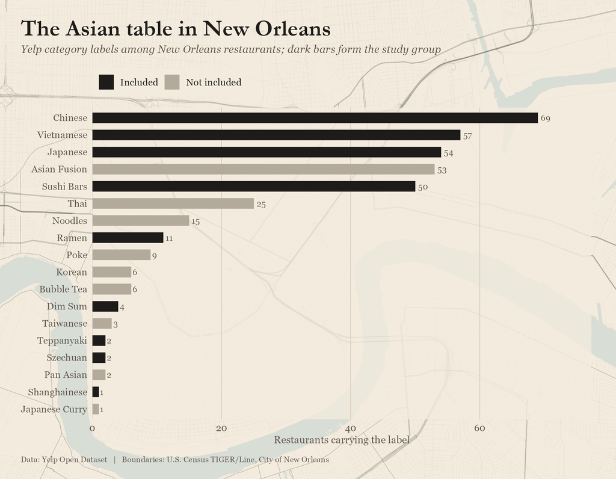

Category counts

```r
tbl("asian_category_pairs") |> slice_head(n = 12) |> show()
```

| category_1 | category_2 | restaurants_with_both |
| --- | --- | --- |
| japanese | sushi bars | 32 |
| asian fusion | japanese | 11 |
| asian fusion | sushi bars | 11 |
| japanese | ramen | 11 |
| asian fusion | chinese | 10 |
| chinese | vietnamese | 9 |
| asian fusion | vietnamese | 7 |
| japanese | noodles | 7 |
| chinese | noodles | 6 |
| asian fusion | noodles | 5 |
| japanese | poke | 5 |
| asian fusion | thai | 4 |

```r
tbl("subcuisine_without_parent") |> show()
```

| category | cuisine | with_label | parent | without_parent |
| --- | --- | --- | --- | --- |
| sushi bars | Japanese | 50 | japanese | 18 |
| ramen | Japanese | 11 | japanese | 0 |
| teppanyaki | Japanese | 2 | japanese | 0 |
| dim sum | Chinese | 4 | chinese | 0 |
| szechuan | Chinese | 2 | chinese | 0 |
| shanghainese | Chinese | 1 | chinese | 0 |

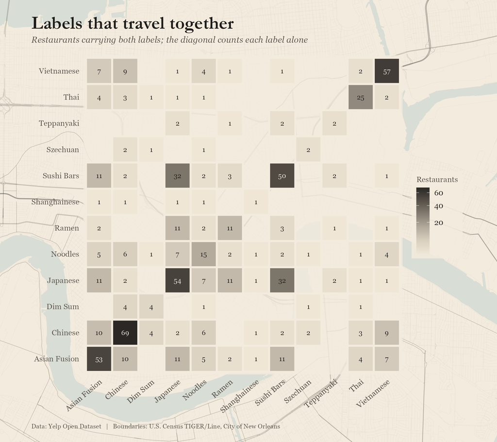

Co-occurrence

**Inclusion rule:** a restaurant is included if it has **at least one** of `Vietnamese`, `Chinese`, `Japanese`, or a sub-cuisine label that belongs to one of them (`Sushi Bars`, `Ramen`, `Dim Sum`, `Szechuan`, `Cantonese`, …). The sub-cuisine table above shows how many sushi bars, ramen shops, etc. would be lost if only the parent label were used. `Asian Fusion` by itself is not enough, because it does not say which cuisine is served.

```r
tbl("inclusion_summary") |> show()
```

| cuisine_group | Other LA city label | Yelp city = New Orleans |
| --- | --- | --- |
| Chinese | 65 | 57 |
| Japanese | 45 | 67 |
| Multiple | 21 | 14 |
| Vietnamese | 46 | 46 |

```r
tbl("requirement_check") |> show()
```

| geographic_system | restaurants_assigned | areas_with_restaurants | meets_requirement |
| --- | --- | --- | --- |
| Neighborhood Statistical Area | 171 | 45 | TRUE |
| ZIP/ZCTA | 171 | 17 | TRUE |
| Census tract | 171 | 70 | TRUE |

## 4. Joining businesses to reviews

[figure not shown]

A city learns to review: cumulative reviews by cuisine

```r
join_chk |> show()
```

| study_restaurants | restaurants_with_reviews | reviews | reviewers | yelp_review_count_total | first_review | last_review |
| --- | --- | --- | --- | --- | --- | --- |
| 171 | 171 | 21,811 | 14,190 | 21,107 | 2005-07-10 | 2022-01-18 |

## 5. Comparing geographic systems

```r
# =============================================================================
# R/03_geography.R
# Spatial joins: (1) Census place boundary to check Yelp's city label,
# (2) three candidate geographic systems compared side by side.
# Inputs : asian_restaurants_la.rds, la_restaurants.rds
# Outputs: study_restaurants.rds, areas_<system>.rds, comparison tables + maps
# Needs internet the first time (tigris + data.nola.gov downloads).
# =============================================================================

source("R/00_setup.R")
sf_use_s2(FALSE)   # everything is projected to UTM metres below

asian_la <- read_rds_clean("asian_restaurants_la")

to_points <- function(df) {
  df |>
    filter(!is.na(longitude), !is.na(latitude)) |>
    st_as_sf(coords = c("longitude", "latitude"), crs = crs_lonlat, remove = FALSE) |>
    st_transform(crs_projected)
}

# ---- 1. Official city boundary (Census TIGER place) -------------------------
la_places <- tigris::places(state = "LA", cb = TRUE, year = 2024, class = "sf") |>
  st_transform(crs_projected) |>
  st_make_valid()
nola_boundary <- la_places |> filter(NAME == "New Orleans") |> select(GEOID, NAME)
save_rds(nola_boundary, "nola_boundary")

asian_pts <- to_points(asian_la) |>
  st_join(la_places |> select(place_geoid = GEOID, place_name = NAME),
          join = st_within, left = TRUE) |>
  mutate(
    place_name = replace_na(place_name, "(outside any Census place)"),
    inside_official_nola = place_name == "New Orleans",
    metres_to_nola_boundary = as.numeric(st_distance(geometry, st_boundary(nola_boundary)))
  )

# Yelp text label versus official polygon
city_vs_place <- asian_pts |>
  st_drop_geometry() |>
  count(yelp_city = city_clean, census_place = place_name, sort = TRUE)
save_table(city_vs_place, "city_vs_place")

label_agreement <- asian_pts |>
  st_drop_geometry() |>
  count(yelp_says_new_orleans, inside_official_nola) |>
  mutate(meaning = case_when(
    yelp_says_new_orleans & inside_official_nola   ~ "Agree: New Orleans",
    yelp_says_new_orleans & !inside_official_nola  ~ "Yelp says New Orleans, point is outside the city",
    !yelp_says_new_orleans & inside_official_nola  ~ "Point is inside the city, Yelp uses another label",
    TRUE ~ "Agree: not New Orleans"
  ))
save_table(label_agreement, "label_agreement")

mismatches <- asian_pts |>
  st_drop_geometry() |>
  filter(yelp_says_new_orleans != inside_official_nola) |>
  select(business_name, address, city_clean, postal_code, place_name,
         metres_to_nola_boundary, review_count) |>
  arrange(metres_to_nola_boundary)
save_table(mismatches, "label_mismatches")

# STUDY DEFINITION: a "New Orleans" restaurant is one whose coordinates fall
# inside the official City of New Orleans (= Orleans Parish) boundary.
# This matches the area covered by every geographic system below.
study_pts <- asian_pts |> filter(inside_official_nola)

# ---- 2. Candidate geographic systems ----------------------------------------
# All systems are clipped to the city boundary so they cover the same land.
prep_areas <- function(x, id_col, name_col, system) {
  x <- x |>
    st_transform(crs_projected) |>
    st_make_valid() |>
    transmute(area_id   = as.character(.data[[id_col]]),
              area_name = as.character(.data[[name_col]]))
  x <- suppressWarnings(st_intersection(x, st_geometry(nola_boundary)))
  x <- x[as.numeric(st_area(x)) > 2e5, ]          # drop slivers < 0.2 km²
  x |>
    group_by(area_id, area_name) |>
    summarise(.groups = "drop") |>
    mutate(system = system,
           area_km2 = round(as.numeric(st_area(geometry)) / 1e6, 2))
}

# (a) Neighborhood Statistical Areas (City of New Orleans / GNOCDC)
nsa_file <- file.path(boundary_dir, "neighborhood_statistical_areas.geojson")
if (!file.exists(nsa_file)) {
  urls <- c(
    "https://data.nola.gov/api/geospatial/exvn-jeh2?method=export&format=GeoJSON",
    "https://data.nola.gov/api/v3/views/exvn-jeh2/query.geojson?accessType=DOWNLOAD"
  )
  for (u in urls) {
    ok <- tryCatch({ download.file(u, nsa_file, mode = "wb", quiet = TRUE); TRUE },
                   error = function(e) FALSE)
    if (ok && file.size(nsa_file) > 1000) break
  }
}
if (!file.exists(nsa_file) || file.size(nsa_file) < 1000) {
  stop("Download the Neighborhood Statistical Area layer manually from ",
       "https://data.nola.gov/d/exvn-jeh2 (Export -> GeoJSON) and save it as ", nsa_file)
}
nsa_raw <- st_read(nsa_file, quiet = TRUE)
nsa_name_col <- names(nsa_raw)[match(c("gnocdc_lab", "lup_lab", "nbhd_name", "name"),
                                     str_to_lower(names(nsa_raw)))]
nsa_name_col <- nsa_name_col[!is.na(nsa_name_col)][1]
stopifnot("Could not find the neighborhood name column; check names(nsa_raw)" = !is.na(nsa_name_col))
nsa_raw$nsa_label <- str_to_title(nsa_raw[[nsa_name_col]])
areas_nsa <- prep_areas(nsa_raw, "nsa_label", "nsa_label", "Neighborhood Statistical Area")

# (b) ZIP Code Tabulation Areas (Census, 2020)
zcta_raw <- tigris::zctas(year = 2020, cb = TRUE, starts_with = c("700", "701"), class = "sf")
zcta_id <- intersect(c("ZCTA5CE20", "GEOID20", "ZCTA5CE10"), names(zcta_raw))[1]
areas_zcta <- prep_areas(zcta_raw, zcta_id, zcta_id, "ZIP/ZCTA") |>
  mutate(area_name = paste("ZIP", area_name))

# (c) Census tracts (Orleans Parish, 2024)
tract_raw <- tigris::tracts(state = "LA", county = "Orleans", year = 2024, cb = TRUE, class = "sf")
areas_tract <- prep_areas(tract_raw, "GEOID", "NAME", "Census tract") |>
  mutate(area_name = paste("Tract", area_name))

area_systems <- list(nsa = areas_nsa, zcta = areas_zcta, tract = areas_tract)
iwalk(area_systems, \(a, nm) save_rds(a, paste0("areas_", nm)))

# ---- 3. Spatial join for each system ----------------------------------------
# st_within first; points that fall in a gap (exactly on a line, or in a
# clipped sliver) get the nearest area if it is within 100 m, and are flagged.
assign_area <- function(points, areas) {
  joined <- st_join(points, areas |> select(area_id, area_name), join = st_within, left = TRUE) |>
    distinct(business_id, .keep_all = TRUE)
  gap <- is.na(joined$area_id)
  if (any(gap)) {
    nearest <- st_nearest_feature(joined[gap, ], areas)
    dist <- as.numeric(st_distance(joined[gap, ], areas[nearest, ], by_element = TRUE))
    fix <- dist <= 100
    joined$area_id[which(gap)[fix]]   <- areas$area_id[nearest[fix]]
    joined$area_name[which(gap)[fix]] <- areas$area_name[nearest[fix]]
  }
  joined$matched_by <- case_when(!gap ~ "within", !is.na(joined$area_id) ~ "nearest <= 100 m",
                                 TRUE ~ "unmatched")
  joined
}
```

```r
assigned <- map(area_systems, \(a) assign_area(study_pts, a))

compare_system <- function(pts, areas) {
  per_area <- areas |>
    st_drop_geometry() |>
    left_join(pts |> st_drop_geometry() |> filter(!is.na(area_id)) |>
                group_by(area_id) |>
                summarise(restaurants = n(), mean_stars = mean(stars), .groups = "drop"),
              by = "area_id") |>
    mutate(restaurants = replace_na(restaurants, 0L))
  occupied <- per_area |> filter(restaurants > 0)
  rankable <- occupied |> filter(restaurants >= min_restaurants_area)
  tibble(
    geographic_system      = areas$system[1],
    number_of_areas        = nrow(areas),
    areas_with_restaurants = nrow(occupied),
    restaurants_assigned   = sum(!is.na(pts$area_id)),
    assigned_by_nearest    = sum(pts$matched_by == "nearest <= 100 m"),
    unmatched_restaurants  = sum(is.na(pts$area_id)),
    smallest_area_count    = min(occupied$restaurants),
    median_area_count      = median(occupied$restaurants),
    largest_area_count     = max(occupied$restaurants),
    areas_rankable         = nrow(rankable),
    median_area_km2        = median(areas$area_km2),
    spread_of_area_mean_stars = round(sd(rankable$mean_stars), 2)
  )
}

geo_comparison <- map2(assigned, area_systems, compare_system) |> list_rbind()
save_table(geo_comparison, "geography_comparison")
geo_comparison

# Requirement check: >= 10 restaurants in >= 7 areas
requirement_check <- geo_comparison |>
  transmute(geographic_system, restaurants_assigned, areas_with_restaurants,
            meets_requirement = restaurants_assigned >= 10 & areas_with_restaurants >= 7)
save_table(requirement_check, "requirement_check")

# Keep each system's assignment as a column on one study table
study_restaurants <- study_pts |>
  left_join(assigned$nsa   |> st_drop_geometry() |> select(business_id, nsa_id = area_id, nsa_name = area_name),
            by = "business_id") |>
  left_join(assigned$zcta  |> st_drop_geometry() |> select(business_id, zcta_id = area_id, zcta_name = area_name),
            by = "business_id") |>
  left_join(assigned$tract |> st_drop_geometry() |> select(business_id, tract_id = area_id, tract_name = area_name),
            by = "business_id")
save_rds(study_restaurants, "study_restaurants")

# ---- 4. Base layers for artistic maps: the river and major roads -----------
# The Mississippi's crescent is what gives the "Crescent City" its name, so it
# anchors every map. Roads are drawn as faint ink strokes for orientation.
map_frame <- st_buffer(nola_boundary, 6000)
nola_water <- tryCatch({
  w <- tigris::area_water(state = "LA",
                          county = c("Orleans", "Jefferson", "St. Bernard", "St. Tammany", "Plaquemines"),
                          year = 2024, class = "sf") |>
    st_transform(crs_projected) |> st_make_valid()
  w <- suppressWarnings(st_intersection(w, st_geometry(map_frame)))
  w[as.numeric(st_area(w)) > 3e5, ]
}, error = function(e) { message("Water layer skipped: ", conditionMessage(e)); NULL })
# Every street (TIGER/Line "All Roads") in Orleans and its neighboring
# parishes, so the street grid continues past the city line like a real map.
# MTFCC codes: S1100 = interstate, S1200 = major road, S1400 = local street.
street_frame <- st_buffer(nola_boundary, 4000)
nola_roads <- tryCatch({
  map(c("Orleans", "Jefferson", "St. Bernard", "Plaquemines"),
      \(cty) tigris::roads(state = "LA", county = cty, year = 2024, class = "sf")) |>
    list_rbind() |> st_as_sf() |>
    st_transform(crs_projected) |>
    select(FULLNAME, MTFCC) |>
    st_filter(street_frame) |>
    mutate(road_class = case_when(MTFCC == "S1100" ~ "interstate",
                                  MTFCC %in% c("S1200", "S1630") ~ "major",
                                  TRUE ~ "local"))
}, error = function(e) {
  message("Full street layer failed (", conditionMessage(e), "); using major roads only")
  tryCatch(tigris::primary_secondary_roads(state = "LA", year = 2024, class = "sf") |>
             st_transform(crs_projected) |> st_filter(street_frame) |>
             mutate(road_class = if_else(MTFCC == "S1100", "interstate", "major")),
           error = function(e) NULL)
})
save_rds(nola_water, "nola_water")
save_rds(nola_roads, "nola_roads")

# ---- 5. One map per system --------------------------------------------------
map_system <- function(pts, areas) {
  counts <- areas |>
    left_join(pts |> st_drop_geometry() |> count(area_id, name = "restaurants"), by = "area_id") |>
    mutate(restaurants = replace_na(restaurants, 0L))
  ggplot() +
    ink_base(nola_boundary, nola_water, nola_roads,
             geom_sf(data = counts, aes(fill = restaurants), colour = paper, linewidth = 0.35)) +
    geom_sf(data = pts, aes(colour = cuisine_group, shape = cuisine_group), size = 1.7, alpha = 0.9) +
    scale_fill_stepsn(colours = ink_wash[1:5], name = "Restaurants\nper area", n.breaks = 5) +
    scale_colour_manual(values = cuisine_colors, name = "Cuisine") +
    scale_shape_manual(values = cuisine_shapes_solid, name = "Cuisine") +
    labs(title = areas$system[1],
         subtitle = paste0(nrow(areas), " areas, ", sum(counts$restaurants == 0),
                           " with no Vietnamese, Chinese or Japanese restaurant"),
         caption = data_caption) +
    theme_ink_map(11)
}
iwalk(names(area_systems), \(nm, i) save_fig(map_system(assigned[[nm]], area_systems[[nm]]),
                                             paste0("map_counts_", nm), width = 8, height = 7,
                                             basemap = FALSE))

# Label check map: where does Yelp's "New Orleans" disagree with the boundary?
label_pts <- asian_pts |>
  filter(yelp_says_new_orleans | inside_official_nola) |>
  mutate(where = if_else(inside_official_nola, "Inside the city boundary", "Outside the city boundary"))
p_labels <- ggplot() +
  ink_base(nola_boundary, nola_water, nola_roads) +
  geom_sf(data = label_pts, aes(colour = where, shape = where), size = 1.8, alpha = 0.85) +
  scale_colour_manual(values = c("Inside the city boundary" = cuisine_colors[["Vietnamese"]],
                                 "Outside the city boundary" = seal_red), name = NULL) +
  scale_shape_manual(values = c("Inside the city boundary" = 16,
                                "Outside the city boundary" = 4), name = NULL) +
  labs(title = "Where Yelp's “New Orleans” really is",
       subtitle = "Restaurants labeled New Orleans by Yelp, checked against the official city line",
       caption = data_caption) +
  theme_ink_map(11) + theme(legend.position = "bottom")
save_fig(p_labels, "map_label_check", width = 8, height = 7, basemap = FALSE)
```

```r
geo |> show()
```

| geographic_system | number_of_areas | areas_with_restaurants | restaurants_assigned | assigned_by_nearest | unmatched_restaurants | smallest_area_count | median_area_count | largest_area_count | areas_rankable | median_area_km2 | spread_of_area_mean_stars |
| --- | --- | --- | --- | --- | --- | --- | --- | --- | --- | --- | --- |
| Neighborhood Statistical Area | 70 | 45 | 171 | 0 | 0 | 1 | 2.0 | 30 | 18 | 2.4 | 0.25 |
| ZIP/ZCTA | 18 | 17 | 171 | 1 | 0 | 2 | 6.0 | 38 | 14 | 13.7 | 0.19 |
| Census tract | 182 | 70 | 171 | 0 | 0 | 1 | 1.5 | 30 | 18 | 0.8 | 0.40 |

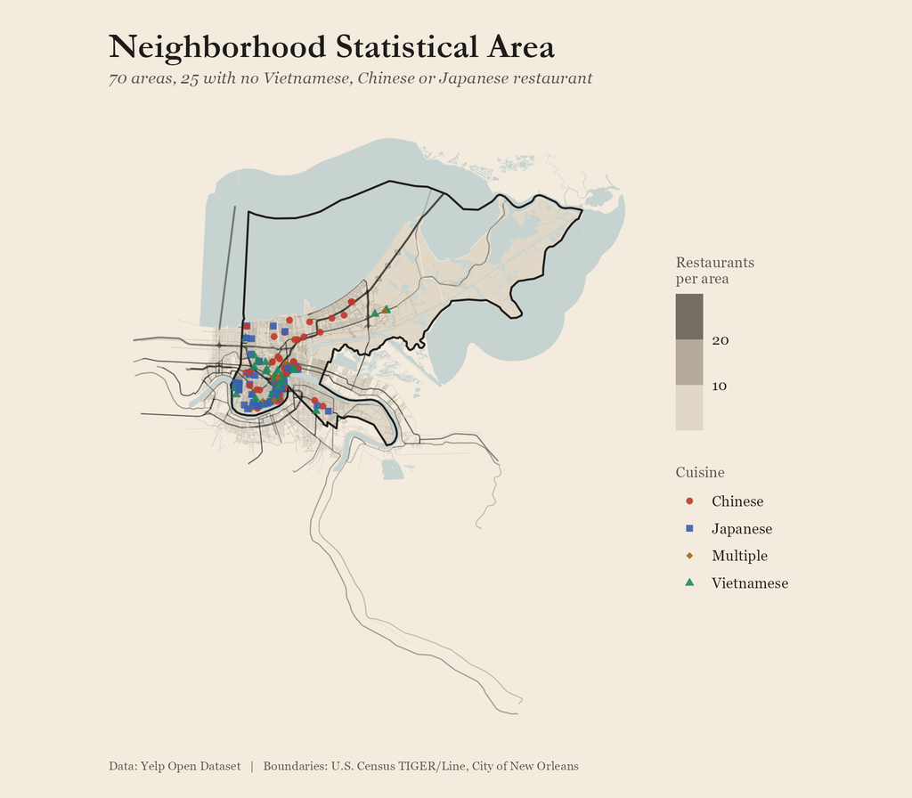

Neighborhood Statistical Areas

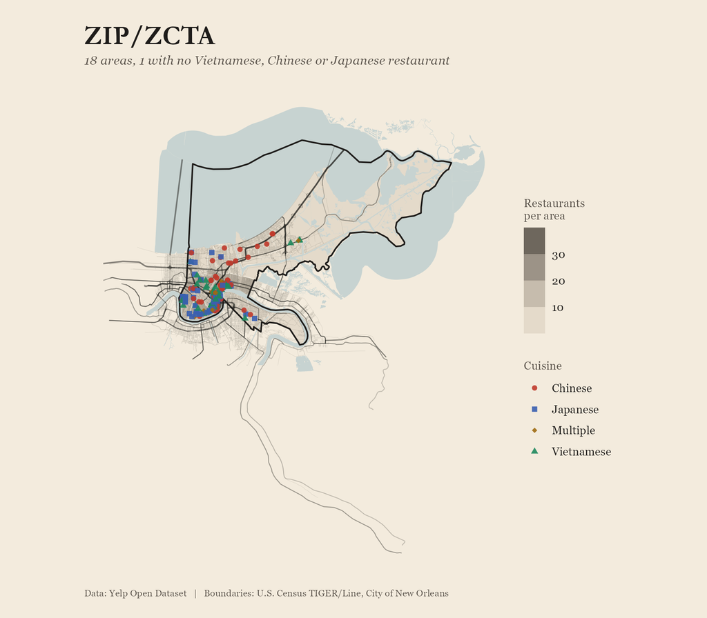

ZIP/ZCTA

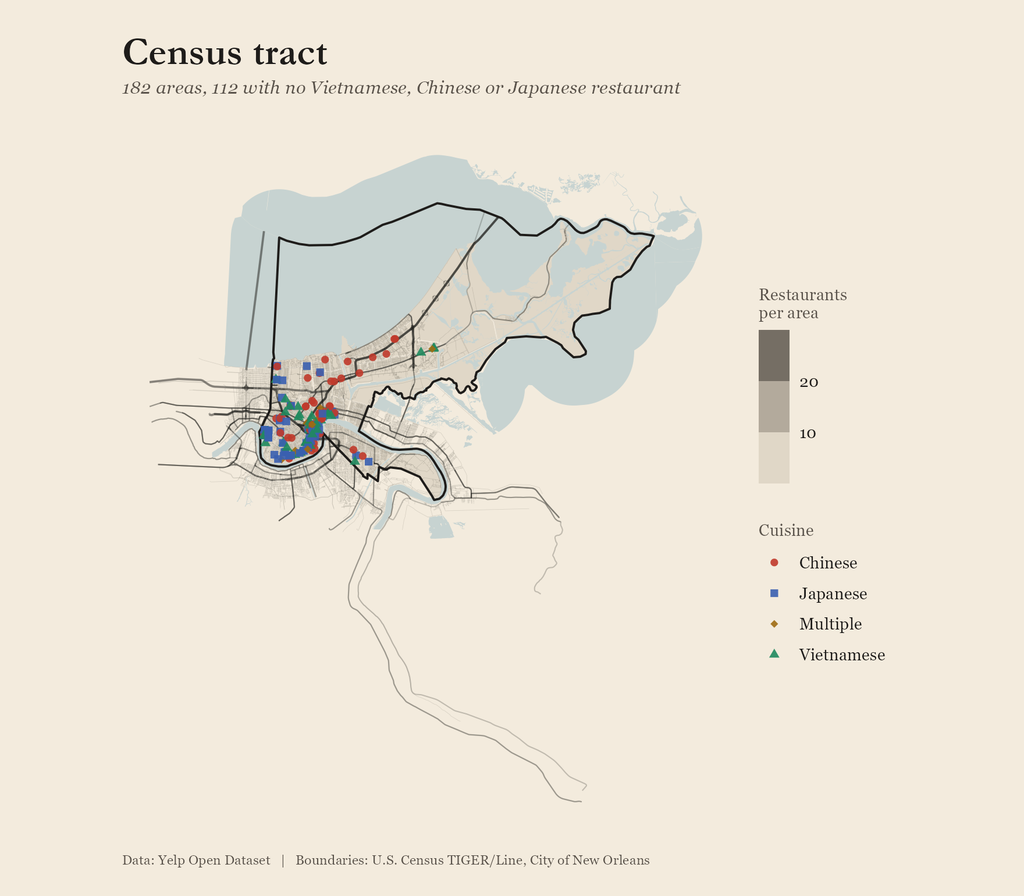

Census tracts

```r
tbl("area_answer_by_system") |> show()
```

| area | restaurants | top_quartile | system |
| --- | --- | --- | --- |
| Central Business District | 30 | 4 | nsa |
| Leonidas | 12 | 2 | nsa |
| Lower Garden District | 12 | 2 | nsa |
| ZIP 70130 | 38 | 4 | zcta |
| ZIP 70115 | 20 | 3 | zcta |
| ZIP 70117 | 13 | 3 | zcta |
| Tract 134 | 30 | 4 | tract |
| Tract 129 | 11 | 2 | tract |
| Tract 82 | 5 | 2 | tract |

## 6. All reviewers vs. selected reviewers

```r
# =============================================================================
# R/04_analysis.R
# Reviews joined to the study restaurants; all-reviewer vs. eligible-reviewer
# results; reviewer-normalized scores; top 10; best area; figures.
# Inputs : study_restaurants.rds, la_restaurant_reviews.rds, areas_*.rds
# =============================================================================

source("R/00_setup.R")
sf_use_s2(FALSE)

study    <- read_rds_clean("study_restaurants")
areas    <- read_rds_clean(paste0("areas_", main_geography))
nola     <- read_rds_clean("nola_boundary")
la_reviews <- read_rds_clean("la_restaurant_reviews")

area_id_col   <- paste0(main_geography, "_id")
area_name_col <- paste0(main_geography, "_name")
study <- study |>
  mutate(area_id = .data[[area_id_col]], area_name = .data[[area_name_col]])
study_tbl <- st_drop_geometry(study)

# ---- 1. Join: filter reviews to the study restaurants (one-to-many) ---------
category_reviews <- la_reviews |>
  semi_join(study_tbl, by = "business_id") |>
  mutate(review_date = as_date(ymd_hms(date, quiet = TRUE)),
         review_year = year(review_date))
rm(la_reviews); invisible(gc())

join_check <- tibble(
  study_restaurants          = nrow(study_tbl),
  restaurants_with_reviews   = n_distinct(category_reviews$business_id),
  reviews                    = nrow(category_reviews),
  reviewers                  = n_distinct(category_reviews$user_id),
  yelp_review_count_total    = sum(study_tbl$review_count),
  first_review = min(category_reviews$review_date, na.rm = TRUE),
  last_review  = max(category_reviews$review_date, na.rm = TRUE)
)
save_table(join_check, "join_check")

# ---- 2. All reviewers -------------------------------------------------------
all_reviewer_summary <- category_reviews |>
  group_by(business_id) |>
  summarise(
    number_of_reviews_all_reviewers = n(),
    average_stars_all_reviewers     = mean(stars),
    median_stars_all_reviewers      = median(stars),
    .groups = "drop"
  )

# ---- 3. Reviewer baselines and normalized scores ----------------------------
# Baseline = the reviewer's own mean (and median) within this category group.
# Primary score uses the MEAN: Yelp stars are integers, so a median baseline
# makes most normalized scores exactly 0 and hides small differences.
reviewer_baselines <- category_reviews |>
  group_by(user_id) |>
  summarise(reviewer_mean = mean(stars), reviewer_median = median(stars),
            reviewer_review_count = n(), .groups = "drop")

category_reviews_adjusted <- category_reviews |>
  left_join(reviewer_baselines, by = "user_id") |>
  mutate(normalized_mean_score   = stars - reviewer_mean,
         normalized_median_score = stars - reviewer_median)

eligible_reviewers <- reviewer_baselines |>
  filter(reviewer_review_count >= min_reviewer_reviews)
eligible_adjusted_reviews <- category_reviews_adjusted |>
  semi_join(eligible_reviewers, by = "user_id")

reviewer_retention <- tibble(
  threshold = threshold_grid,
  reviewers_kept = map_int(threshold_grid, \(t) sum(reviewer_baselines$reviewer_review_count >= t)),
  reviews_kept   = map_int(threshold_grid, \(t) sum(category_reviews_adjusted$reviewer_review_count >= t)),
  restaurants_with_5plus_eligible = map_int(threshold_grid, \(t) {
    category_reviews_adjusted |> filter(reviewer_review_count >= t) |>
      count(business_id) |> filter(n >= 5) |> nrow()
  })
) |>
  mutate(pct_reviewers = reviewers_kept / n_distinct(category_reviews$user_id),
         pct_reviews   = reviews_kept / nrow(category_reviews))
save_table(reviewer_retention, "reviewer_retention")

# ---- 4. Restaurant-level comparison -----------------------------------------
global_mean <- mean(category_reviews$stars)

summarise_eligible <- function(reviews) {
  reviews |>
    group_by(business_id) |>
    summarise(
      number_of_reviews_eligible_reviewers = n(),
      average_stars_eligible_reviewers     = mean(stars),
      average_normalized_score             = mean(normalized_mean_score),
      median_normalized_score              = median(normalized_mean_score),
      average_normalized_median_score      = mean(normalized_median_score),
      sum_normalized                       = sum(normalized_mean_score),
      .groups = "drop"
    )
}

restaurant_summary <- study_tbl |>
  select(business_id, business_name, address, cuisines, cuisine_group, is_open,
         latitude, longitude, area_id, area_name, business_stars = stars) |>
  left_join(all_reviewer_summary, by = "business_id") |>
  left_join(summarise_eligible(eligible_adjusted_reviews), by = "business_id") |>
  mutate(
    across(c(number_of_reviews_all_reviewers, number_of_reviews_eligible_reviewers),
           \(x) replace_na(x, 0L)),
    # Reliability: shrink small samples toward the group mean (raw) or 0 (adjusted)
    shrunk_stars = (average_stars_all_reviewers * number_of_reviews_all_reviewers +
                      shrink_k * global_mean) / (number_of_reviews_all_reviewers + shrink_k),
    shrunk_adjusted = replace_na(sum_normalized, 0) /
      (number_of_reviews_eligible_reviewers + shrink_k),
    rankable = is_open == 1 &
      number_of_reviews_all_reviewers >= min_reviews_to_rank &
      number_of_reviews_eligible_reviewers >= min_eligible_to_rank
  )

# "Best" = average of two percentile ranks among rankable restaurants:
#   reliability-adjusted raw stars (what diners see) and the reliability-
#   adjusted reviewer-normalized score (did reviewers like it MORE than usual?)
ranked <- restaurant_summary |>
  filter(rankable) |>
  mutate(
    pct_raw      = percent_rank(shrunk_stars),
    pct_adjusted = percent_rank(shrunk_adjusted),
    best_score   = (pct_raw + pct_adjusted) / 2,
    rank_raw      = min_rank(desc(average_stars_all_reviewers)),
    rank_adjusted = min_rank(desc(average_normalized_score)),
    rank_change   = rank_raw - rank_adjusted
  ) |>
  # ties are broken by review volume (more evidence wins)
  arrange(desc(best_score), desc(number_of_reviews_all_reviewers)) |>
  mutate(rank_best = row_number())
```

```r
restaurant_summary <- restaurant_summary |>
  left_join(ranked |> select(business_id, pct_raw, pct_adjusted, best_score,
                             rank_raw, rank_adjusted, rank_change, rank_best),
            by = "business_id")
save_rds(restaurant_summary, "restaurant_summary")

top10 <- ranked |>
  slice_head(n = 10) |>
  transmute(rank = rank_best, restaurant = business_name, cuisine = cuisines, cuisine_group, area = area_name,
            address, reviews = number_of_reviews_all_reviewers,
            avg_stars = round(average_stars_all_reviewers, 2),
            eligible_reviews = number_of_reviews_eligible_reviewers,
            avg_normalized = round(average_normalized_score, 2),
            best_score = round(best_score, 3),
            latitude, longitude)
save_table(top10, "top10_restaurants")

big_movers <- ranked |>
  filter(abs(rank_change) >= quantile(abs(rank_change), 0.9)) |>
  transmute(restaurant = business_name, area = area_name,
            reviews = number_of_reviews_all_reviewers,
            eligible_reviews = number_of_reviews_eligible_reviewers,
            avg_stars = round(average_stars_all_reviewers, 2),
            avg_normalized = round(average_normalized_score, 2),
            rank_raw, rank_adjusted, rank_change) |>
  arrange(desc(abs(rank_change)))
save_table(big_movers, "rank_changes")

# Threshold sensitivity: how many of today's top 10 survive other thresholds?
top10_at <- function(t) {
  elig <- category_reviews_adjusted |> filter(reviewer_review_count >= t)
  restaurant_summary |>
    select(business_id, is_open, number_of_reviews_all_reviewers, shrunk_stars) |>
    left_join(summarise_eligible(elig), by = "business_id") |>
    mutate(n_e = replace_na(number_of_reviews_eligible_reviewers, 0L),
           adj = replace_na(sum_normalized, 0) / (n_e + shrink_k)) |>
    filter(is_open == 1, number_of_reviews_all_reviewers >= min_reviews_to_rank,
           n_e >= min_eligible_to_rank) |>
    mutate(score = (percent_rank(shrunk_stars) + percent_rank(adj)) / 2) |>
    slice_max(score, n = 10, with_ties = FALSE) |>
    pull(business_id)
}
main_top <- top10_at(min_reviewer_reviews)
threshold_sensitivity <- tibble(threshold = threshold_grid) |>
  mutate(overlap_with_main_top10 = map_int(threshold, \(t) length(intersect(top10_at(t), main_top))))
save_table(threshold_sensitivity, "threshold_sensitivity")

# ---- 5. Which area is best? -------------------------------------------------
# An area is good for finding these restaurants if it has MANY top-quartile
# restaurants (choice), not just one lucky high average.
area_summary <- restaurant_summary |>
  filter(!is.na(area_id)) |>
  group_by(area_id, area_name) |>
  summarise(
    restaurants          = n(),
    open_restaurants     = sum(is_open == 1),
    reviews              = sum(number_of_reviews_all_reviewers),
    review_weighted_stars = weighted.mean(average_stars_all_reviewers,
                                          number_of_reviews_all_reviewers, na.rm = TRUE),
    mean_normalized      = weighted.mean(average_normalized_score,
                                         number_of_reviews_eligible_reviewers, na.rm = TRUE),
    top_quartile_restaurants = sum(best_score >= 0.75, na.rm = TRUE),
    top10_restaurants    = sum(rank_best <= 10, na.rm = TRUE),
    cuisines_present     = n_distinct(cuisine_group),
    .groups = "drop"
  ) |>
  mutate(rankable_area = restaurants >= min_restaurants_area,
         share_top_quartile = top_quartile_restaurants / restaurants) |>
  arrange(desc(rankable_area), desc(top_quartile_restaurants), desc(review_weighted_stars))
save_table(area_summary, paste0("area_summary_", main_geography))

# Same summary under every system (does the answer depend on the boundaries?)
area_answer_by_system <- map(c("nsa", "zcta", "tract"), \(g) {
  restaurant_summary |>
    select(business_id, best_score) |>
    left_join(study_tbl |> select(business_id, area = all_of(paste0(g, "_name"))), by = "business_id") |>
    filter(!is.na(area)) |>
    group_by(area) |>
    summarise(restaurants = n(), top_quartile = sum(best_score >= 0.75, na.rm = TRUE), .groups = "drop") |>
    filter(restaurants >= min_restaurants_area) |>
    slice_max(top_quartile, n = 3, with_ties = FALSE) |>
    mutate(system = g)
}) |> list_rbind()
save_table(area_answer_by_system, "area_answer_by_system")

# ---- 6. Figures (Ink & Lacquer style, see R/00_theme.R) ---------------------
water_sf <- read_rds_clean("nola_water")
roads_sf <- read_rds_clean("nola_roads")

# 6a. Candidate category counts
cand <- read_csv(file.path(table_dir, "asian_candidate_counts.csv"), show_col_types = FALSE)
p_cats <- cand |>
  slice_max(restaurants, n = 18) |>
  mutate(category = fct_reorder(str_to_title(category), restaurants),
         status = if_else(selected, "Included", "Not included")) |>
  ggplot(aes(restaurants, category, fill = status)) +
  geom_col(width = 0.62) +
  geom_text(aes(label = restaurants), hjust = -0.3, size = 3.2, colour = ink_soft, family = font_body) +
  scale_fill_manual(values = c(Included = ink, `Not included` = ink_wash[3]), name = NULL) +
  scale_x_continuous(expand = expansion(mult = c(0, 0.12))) +
  labs(title = "The Asian table in New Orleans",
       subtitle = "Yelp category labels among New Orleans restaurants; dark bars form the study group",
       x = "Restaurants carrying the label", y = NULL, caption = data_caption) +
  theme_ink() +
  theme(legend.position = "top", legend.justification = "left", panel.grid.major.y = element_blank())
save_fig(p_cats, "category_counts", width = 9, height = 7)

# 6b. Co-occurrence: an ink-wash grid
pm <- read_rds_clean("asian_pair_matrix") |>
  filter(category.x %in% cand$category[cand$selected | cand$restaurants >= 10],
         category.y %in% cand$category[cand$selected | cand$restaurants >= 10]) |>
  mutate(across(c(category.x, category.y), str_to_title))
p_pairs <- ggplot(pm, aes(category.x, category.y, fill = restaurants)) +
  geom_tile(colour = paper, linewidth = 1.2) +
  geom_text(aes(label = restaurants, colour = restaurants > 0.65 * max(restaurants)),
            size = 3.2, family = font_body, show.legend = FALSE) +
  scale_fill_gradientn(colours = ink_wash, trans = "sqrt", name = "Restaurants") +
  scale_colour_manual(values = c(`TRUE` = paper, `FALSE` = ink)) +
  coord_fixed() +
  labs(title = "Labels that travel together",
       subtitle = "Restaurants carrying both labels; the diagonal counts each label alone",
       x = NULL, y = NULL, caption = data_caption) +
  theme_ink() +
  theme(axis.text.x = element_text(angle = 40, hjust = 1),
        panel.grid = element_blank(), panel.grid.major = element_blank())
save_fig(p_pairs, "category_cooccurrence", width = 9, height = 8)
```

```r
# 6c. Raw vs adjusted
scatter_data <- restaurant_summary |>
  filter(number_of_reviews_eligible_reviewers >= min_eligible_to_rank)
p_scatter <- ggplot(scatter_data, aes(average_stars_all_reviewers, average_normalized_score)) +
  geom_hline(yintercept = 0, colour = ink_soft, linewidth = 0.4, linetype = "22") +
  annotate("text", x = min(scatter_data$average_stars_all_reviewers, na.rm = TRUE), y = 0,
           label = "rated exactly as these reviewers usually rate", vjust = -0.6, hjust = 0,
           family = font_body, fontface = "italic", size = 3, colour = ink_soft) +
  geom_point(aes(size = number_of_reviews_all_reviewers, fill = cuisine_group, shape = cuisine_group),
             colour = paper, stroke = 0.5, alpha = 0.9) +
  geom_text_repel(data = \(d) d |> filter(rank_best <= 10),
                  aes(label = business_name), family = font_display, fontface = "bold",
                  size = 3.6, colour = ink, max.overlaps = 30, seed = 42,
                  segment.colour = ink_soft, segment.size = 0.3) +
  scale_fill_manual(values = cuisine_colors, name = "Cuisine") +
  scale_shape_manual(values = cuisine_shapes, name = "Cuisine") +
  scale_size_area(max_size = 9, name = "Reviews", labels = label_comma()) +
  guides(fill  = guide_legend(override.aes = list(size = 4)),
         size  = guide_legend(override.aes = list(shape = 21, fill = ink_soft))) +
  labs(title = "Praise from the regulars",
       subtitle = "Above the line, experienced reviewers liked a restaurant more than they usually like these cuisines",
       x = "Average stars, all reviewers", y = "Reviewer-adjusted score", caption = data_caption) +
  theme_ink()
save_fig(p_scatter, "raw_vs_adjusted", width = 10, height = 7)

# 6d. Threshold sensitivity
p_thresh <- reviewer_retention |>
  select(threshold, `Reviewers kept` = pct_reviewers, `Reviews kept` = pct_reviews) |>
  pivot_longer(-threshold) |>
  ggplot(aes(factor(threshold), value, fill = name)) +
  geom_col(position = position_dodge(width = 0.72), width = 0.66, colour = paper, linewidth = 0.6) +
  geom_text(aes(label = percent(value, 1)), position = position_dodge(width = 0.72),
            vjust = -0.5, size = 3.2, family = font_body, colour = ink_soft) +
  scale_y_continuous(labels = percent, expand = expansion(mult = c(0, 0.1))) +
  scale_fill_manual(values = c(`Reviewers kept` = ink_wash[3], `Reviews kept` = ink), name = NULL) +
  labs(title = "How strict should we be?",
       subtitle = "Share of reviewers and reviews kept at each activity threshold",
       x = "Minimum reviews per reviewer within this cuisine group", y = NULL, caption = data_caption) +
  theme_ink() +
  theme(legend.position = "top", legend.justification = "left", panel.grid.major.x = element_blank())
save_fig(p_thresh, "threshold_retention", width = 9, height = 6)

# 6e. Best areas: top-quartile restaurants, stacked by cuisine
best_area_ids <- area_summary |>
  filter(rankable_area) |>
  slice_max(top_quartile_restaurants, n = 12, with_ties = FALSE)
p_area <- restaurant_summary |>
  filter(area_id %in% best_area_ids$area_id, best_score >= 0.75) |>
  count(area_name, cuisine_group) |>
  mutate(area_name = fct_reorder(area_name, n, sum)) |>
  ggplot(aes(n, area_name, fill = cuisine_group)) +
  geom_col(width = 0.62, colour = paper, linewidth = 0.6) +
  scale_fill_manual(values = cuisine_colors, name = "Cuisine") +
  scale_x_continuous(breaks = pretty_breaks(), expand = expansion(mult = c(0, 0.05))) +
  labs(title = "Where to go looking",
       subtitle = paste0("Top-quartile restaurants per area (areas with at least ",
                         min_restaurants_area, " restaurants)"),
       x = "Top-quartile restaurants", y = NULL, caption = data_caption) +
  theme_ink() +
  theme(legend.position = "top", legend.justification = "left", panel.grid.major.y = element_blank())
save_fig(p_area, "best_areas", width = 9, height = 6.5)

# 6f. FINAL MAP: top 10 as red seal stamps on an ink-wash city
top10_sf <- top10 |>
  st_as_sf(coords = c("longitude", "latitude"), crs = crs_lonlat) |>
  st_transform(crs_projected)
area_fill <- areas |>
  left_join(area_summary |> select(area_id, top_quartile_restaurants), by = "area_id") |>
  mutate(top_quartile_restaurants = replace_na(top_quartile_restaurants, 0L))
bb <- st_bbox(st_buffer(top10_sf, 2500))
legend_text <- paste0(top10$rank, "  ", top10$restaurant, collapse = "\n")

p_final <- ggplot() +
  ink_base(nola, water_sf, roads_sf,
           geom_sf(data = area_fill, aes(fill = top_quartile_restaurants),
                   colour = paper, linewidth = 0.4)) +
  geom_sf(data = top10_sf, aes(shape = cuisine_group),
          fill = cuisine_colors[top10_sf$cuisine_group], size = 4, colour = paper, stroke = 0.7) +
  geom_seal(data = top10_sf, aes(label = rank, geometry = geometry), stat = "sf_coordinates") +
  scale_fill_stepsn(colours = ink_wash[1:4], name = "Top-quartile\nrestaurants", n.breaks = 4,
                    aesthetics = "fill") +
  scale_shape_manual(values = cuisine_shapes, name = "Cuisine") +
  guides(shape = guide_legend(override.aes = list(fill = cuisine_colors[sort(unique(top10$cuisine_group))]))) +
  annotate("label", x = Inf, y = Inf, label = legend_text, hjust = 1, vjust = 1,
           family = font_display, size = 3.6, lineheight = 1.05, fill = paper,
           colour = ink, label.size = 0, label.r = unit(0, "pt")) +
  coord_sf(xlim = as.numeric(bb[c("xmin", "xmax")]), ylim = as.numeric(bb[c("ymin", "ymax")])) +
  labs(title = "Ten tables worth the trip",
       subtitle = "The best Vietnamese, Chinese & Japanese restaurants in New Orleans. Red seals mark the rank.",
       caption = data_caption) +
  theme_ink_map() +
  theme(legend.position = "bottom", legend.box = "horizontal")
save_fig(p_final, "final_top10_map", width = 10, height = 9, basemap = FALSE)

# 6g. Cover poster: three panels, one per cuisine, like three hanging scrolls
poster_pts <- restaurant_summary |>
  select(business_id, cuisines, longitude, latitude, reviews = number_of_reviews_all_reviewers) |>
  separate_rows(cuisines, sep = " \\+ ") |>
  rename(cuisine = cuisines) |>
  mutate(cuisine = factor(cuisine, levels = c("Vietnamese", "Chinese", "Japanese"))) |>
  st_as_sf(coords = c("longitude", "latitude"), crs = crs_lonlat) |>
  st_transform(crs_projected)
pbb <- st_bbox(st_buffer(poster_pts, 1500))
p_poster <- ggplot() +
  ink_base(nola, water_sf, roads_sf) +
  geom_sf(data = poster_pts, aes(colour = cuisine, size = reviews), alpha = 0.75) +
  scale_colour_manual(values = cuisine_colors, guide = "none") +
  scale_size_area(max_size = 4.5, guide = "none") +
  facet_wrap(~cuisine, nrow = 1) +
  coord_sf(xlim = as.numeric(pbb[c("xmin", "xmax")]), ylim = as.numeric(pbb[c("ymin", "ymax")])) +
  labs(title = "Pho, Dim Sum & Sushi in the Crescent City",
       subtitle = "Every Vietnamese, Chinese and Japanese restaurant on Yelp in New Orleans; larger dots have more reviews",
       caption = data_caption) +
  theme_ink_map(13) +
  theme(panel.spacing = unit(1.2, "lines"),
        panel.background = element_rect(fill = paper_deep, colour = NA),
        strip.text = element_text(size = rel(1.6), margin = margin(b = 6)))
save_fig(p_poster, "cover_poster", width = 14, height = 6.5, basemap = FALSE)
```

```r
message("Done. Tables in ", table_dir, ", figures in ", fig_dir)
```

**Eligible reviewers** wrote at least 5 reviews within this cuisine group. Each review’s **normalized score** is the reviewer’s stars minus that reviewer’s own average for the group. A positive score means the reviewer liked that restaurant *more than they usually like* Vietnamese, Chinese, or Japanese restaurants. This is not a new Yelp rating. The mean baseline is the main one because stars are whole numbers, so a median baseline turns most scores into exactly 0.

```r
retention |> mutate(across(starts_with("pct"), scales::percent)) |> show()
```

| threshold | reviewers_kept | reviews_kept | restaurants_with_5plus_eligible | pct_reviewers | pct_reviews |
| --- | --- | --- | --- | --- | --- |
| 2 | 2,976 | 10,597 | 156 | 21.0% | 49% |
| 3 | 1,352 | 7,349 | 152 | 9.5% | 34% |
| 5 | 503 | 4,496 | 134 | 3.5% | 21% |
| 10 | 131 | 2,156 | 107 | 0.9% | 10% |

```r
tbl("threshold_sensitivity") |> show()
```

| threshold | overlap_with_main_top10 |
| --- | --- |
| 2 | 7 |
| 3 | 7 |
| 5 | 10 |
| 10 | 8 |

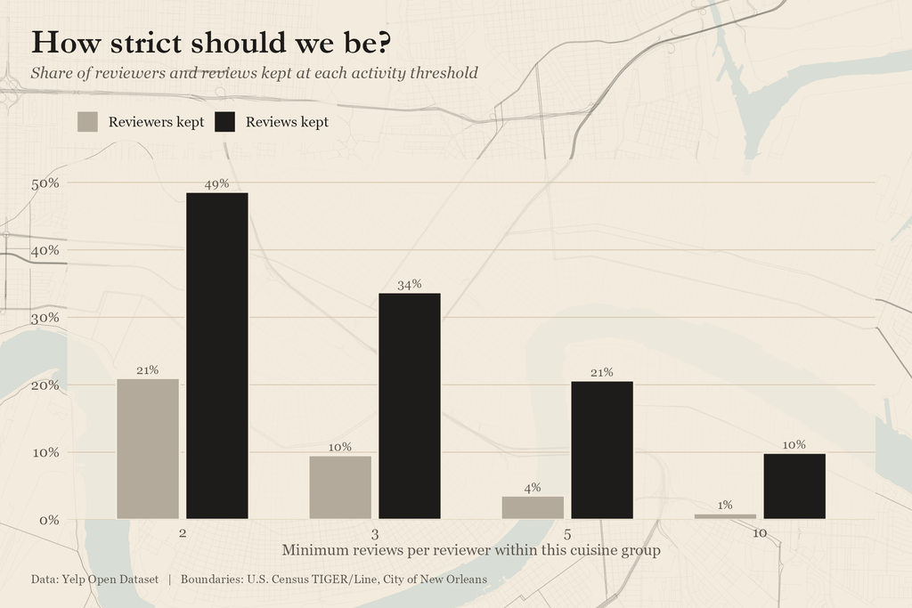

Threshold retention

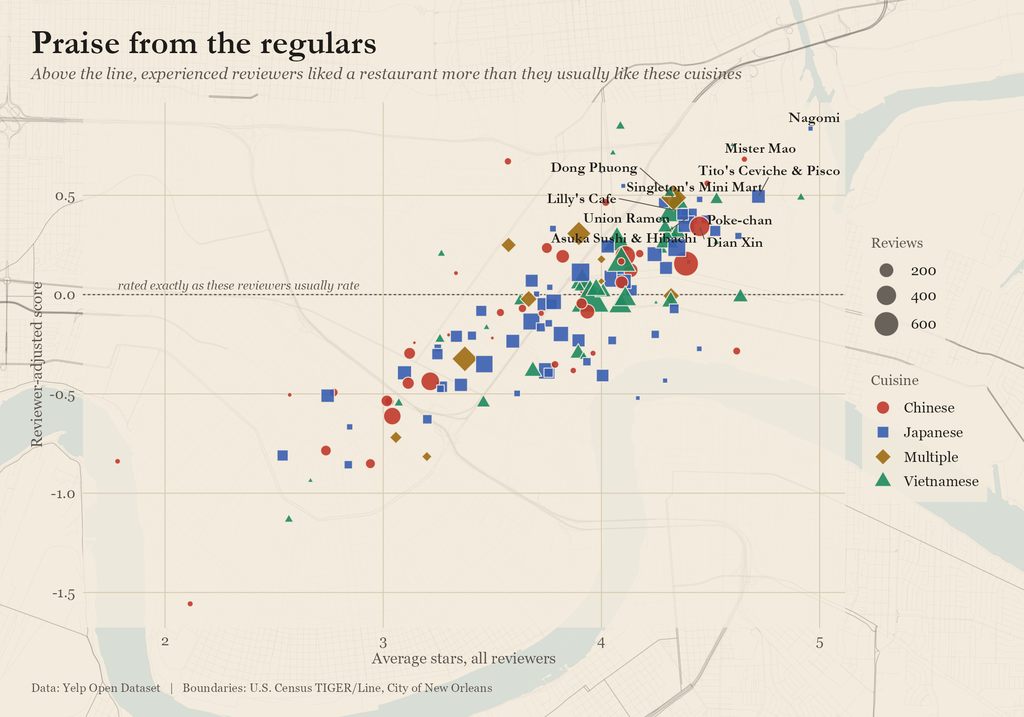

Raw vs adjusted

```r
tbl("rank_changes") |> slice_head(n = 10) |> show()
```

| restaurant | area | reviews | eligible_reviews | avg_stars | avg_normalized | rank_raw | rank_adjusted | rank_change |
| --- | --- | --- | --- | --- | --- | --- | --- | --- |
| Bullard Seafood and Grill | Little Woods | 42 | 6 | 3.57 | 0.67 | 76 | 4 | 72 |
| Zhang Bistro | French Quarter | 50 | 9 | 4.62 | -0.28 | 7 | 69 | -62 |
| Hangout Ramen | Leonidas | 24 | 6 | 4.29 | -0.43 | 29 | 81 | -52 |
| Moon Wok | French Quarter | 141 | 18 | 3.57 | 0.25 | 75 | 27 | 48 |
| Le’s Baguette Banh Mi Cafe | Uptown | 124 | 24 | 4.64 | -0.01 | 5 | 51 | -46 |
| Umi 2 | Tall Timbers - Brechtel | 105 | 21 | 4.33 | -0.07 | 21 | 60 | -39 |
| Frenchmen Grocery & Deli | Marigny | 46 | 5 | 4.09 | 0.85 | 39 | 1 | 38 |
| New China | St. Thomas Dev | 104 | 25 | 3.75 | 0.23 | 65 | 29 | 36 |
| Pho Tau Bay Restaurant | Central Business District | 367 | 88 | 3.90 | 0.31 | 58 | 23 | 35 |
| Haiku Sushi | West Riverside | 184 | 48 | 4.01 | -0.41 | 46 | 80 | -34 |

### How “best” is defined

A restaurant is ranked only if it is still open, has at least 20 reviews, and has at least 3 reviews from eligible reviewers. Two scores are adjusted for reliability by adding 10 “average” pseudo-reviews, so a 5.0 from 4 reviews cannot beat a 4.7 from 400:

1. **raw stars** (what diners see), and
2. **reviewer-normalized score** (did experienced reviewers like it more than usual?).

The final **best score** is the average of the two percentile ranks.

## 7. Which area is best?

```r
tbl(paste0("area_summary_", "nsa")) |>
  filter(rankable_area) |>
  select(area_name, restaurants, reviews, review_weighted_stars,
         mean_normalized, top_quartile_restaurants, top10_restaurants) |>
  slice_head(n = 10) |> show()
```

| area_name | restaurants | reviews | review_weighted_stars | mean_normalized | top_quartile_restaurants | top10_restaurants |
| --- | --- | --- | --- | --- | --- | --- |
| Central Business District | 30 | 3,237 | 3.95 | 0.09 | 4 | 0 |
| St. Claude | 5 | 454 | 4.24 | 0.31 | 2 | 2 |
| Lower Garden District | 12 | 2,102 | 4.09 | 0.13 | 2 | 2 |
| Leonidas | 12 | 1,746 | 3.57 | -0.22 | 2 | 0 |
| Tall Timbers - Brechtel | 3 | 192 | 4.38 | 0.09 | 1 | 0 |
| Uptown | 4 | 521 | 4.29 | 0.15 | 1 | 1 |
| Village De Lest | 4 | 534 | 4.12 | 0.30 | 1 | 1 |
| French Quarter | 10 | 1,111 | 4.12 | 0.20 | 1 | 1 |
| Bayou St. John | 3 | 98 | 3.90 | 0.21 | 1 | 0 |
| Gert Town | 6 | 1,724 | 3.89 | 0.04 | 1 | 1 |

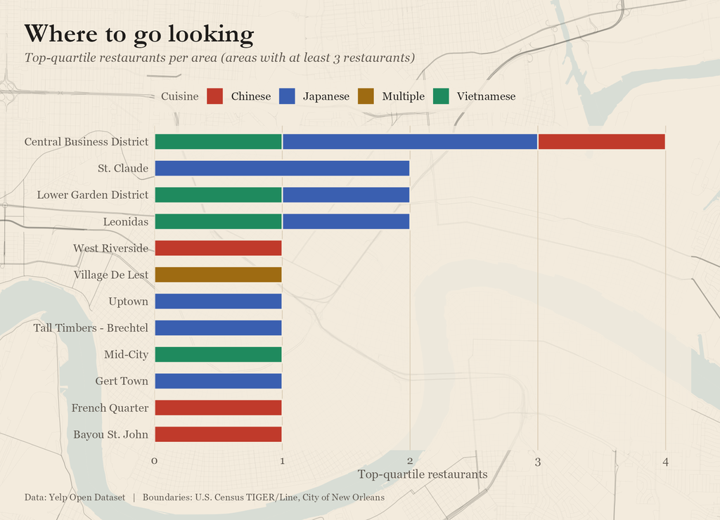

Best areas

## Limitations

- The Yelp Open Dataset is a **snapshot** (reviews end in January 2022). Restaurants may have opened, closed, or changed since then.
- The strongest Vietnamese food scene in the metro area is partly in **Gretna, Marrero, and the West Bank**, which are outside the city boundary and therefore excluded.
- Yelp reviewers are not a random sample of diners; tourists dominate some areas.
- Few reviewers write 5+ reviews in one cuisine group, so the adjusted score rests on a smaller, more local group of reviewers.
- Neighborhood boundaries hide variation within an area, and areas with few restaurants are not ranked.

## AI use

See `ai_prompts.md` for the prompts used and how they were revised.

## Reproducibility

Packages are recorded in `renv.lock`. To reproduce: download the Yelp data into `data/raw/`, then run `source("R/run_all.R")`, then `quarto render yelp_new_orleans_project.qmd --output-dir docs`.